# Space Syntax analysis in R

Workshop in the 12 Space Syntax Symposium

Petros Koutsolampros

Kimon Krenz

July 8, 2019

This document is part of a workshop that presented a workflow for working with spatial data common to the space syntax field in the R programming language. The workshop also introduced participants to the rdepthmap package by Petros Koutsolampros, Fani Kostourou and Kimon Krenz. It aimed to make participants familiar with 1) importing spatial data for urban and building scale, 2) running space syntax analysis with the rdepthmap package and 3) managing and plotting these and other related datasets.

Code is only “run” within chunks. Outside the chunk (like this text) the text is interpreted as Markdown Text (a simple annotation format). Given that the aim of this document is to allow for reproducable workflows, all results and graphs should be created when all the chunks are run in order. Any function used in this document can be found in the Help documentation or by calling the name of the function with a questionmark before it (i.e. ?plot)

## Basic functionality

A data.frame is something akin to an excel sheet, in that it contains tabular data. R provides a few example data.frames, one of which is “cars”. Running the below chunk will print the data.frame underneath.

```r
cars
```

| speed | dist |
| --- | --- |
| 4 | 2 |
| 4 | 10 |
| 7 | 4 |
| 7 | 22 |
| 8 | 16 |
| 9 | 10 |
| 10 | 18 |
| 10 | 26 |
| 10 | 34 |
| 11 | 17 |

[output cut: 40 more lines]

We can see the variable names in the cars data.frame by calling the command names()

```r
names(cars)
```

```
[1] "speed" "dist"
```

To make a simple histogram of one of the variables use the command hist()

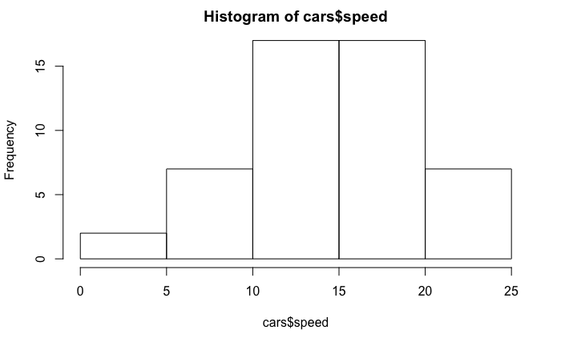

```r
hist(cars$speed)
```

We can load our own data.frame by going to a spreadsheet application (such as excel), creating a few data points and exporting the sheet to a CSV. Then, we can load that CSV in R using read.csv()

```r
newCars <- read.csv("data/newCars.csv")
```

While reading the CSV, R might realise that one (or more) of the columns is categorical (called a factor variable in R) and will thus name it as such (under the column name when printing the data.frame)

```r
newCars
```

| speed | category |
| --- | --- |
| 1 | A |
| 2 | A |
| 3 | B |
| 4 | B |
| 5 | A |
| 6 | C |
| 6 | B |
| 7 | C |
| 8 | C |

In a similar fashion, doing a histogram of one of the variables:

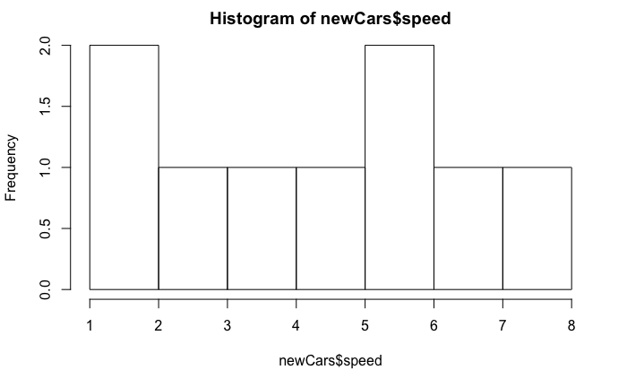

```r
hist(newCars$speed)
```

## Loading spatial data

First let’s load some libraries required later. These should be installed using install.package() i.e. install.package(rgeos), or if using RSTudio from Tools -> Install Packages.. This chunk will also install rdepthmap from github. Its installation requires devtools which should also be installed. On windows [RTools](https://cran.r-project.org/bin/windows/Rtools/) might also need to be installed.

[output not shown]

[output not shown]

[output not shown]

A quick example: Read and plot the classic barnsbury axial map from a pair of MID/MIF files. Adding “verbose = FALSE” to the readOGR will stop it from displaying diagnostic information while reading the MID/MIF files. The size of the plot can be changed by setting fig.width and fig.height in the chunk options as below.

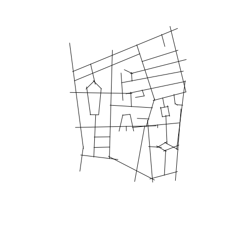

```r
barnsburySmall = readOGR("data/barnsbury/barnsbury_small_axial.mid", verbose = FALSE)
plot(barnsburySmall)
```

Reading spatial data produces a spatial data.frame (in this case a SpatialLinesDataFrame). These spatial data.frames can be examined to see the data or the coordinates. To see the data append @data to the end (for the coordinates, try @lines) which will print the internal data.frame.

```r
barnsburySmall@data
```

|  | Depthmap_Ref | Choice | Choice_Line_Length_Wgt_ | Choice_Line_Length_Wgt_Norm_ | Choice_Norm_ | Connectivity | Integration_HH_ | Line_Length | Mean_Depth | Mean_Depth_Line_Length_Wgt_ | Node_Count | RA | Total_Depth | Total_Line_Length |
| --- | --- | --- | --- | --- | --- | --- | --- | --- | --- | --- | --- | --- | --- | --- |
| 1 | 0 | 182 | 17580946.0 | 0.184802870 | 0.1028248600 | 5 | 1.8732555 | 743.12512 | 2.850000 | 2.212653 | 61 | 0.06271187 | 171 | 13793.73 |
| 2 | 1 | 360 | 25343200.0 | 0.266396140 | 0.2033898200 | 6 | 1.9432838 | 791.05670 | 2.783333 | 2.150709 | 61 | 0.06045198 | 167 | 13793.73 |
| 3 | 2 | 151 | 5913097.0 | 0.062155772 | 0.0853107350 | 4 | 1.3502036 | 147.84348 | 3.566667 | 2.968181 | 61 | 0.08700565 | 214 | 13793.73 |
| 4 | 3 | 123 | 10576759.0 | 0.111178060 | 0.0694915280 | 4 | 1.7621301 | 494.45386 | 2.966667 | 2.378288 | 61 | 0.06666667 | 178 | 13793.73 |
| 5 | 4 | 10 | 1522733.6 | 0.016006280 | 0.0056497175 | 3 | 1.0608743 | 81.98231 | 4.266667 | 3.711566 | 61 | 0.11073446 | 256 | 13793.73 |
| 6 | 5 | 10 | 1555573.4 | 0.016351476 | 0.0056497175 | 3 | 1.0608743 | 87.84889 | 4.266667 | 3.710254 | 61 | 0.11073446 | 256 | 13793.73 |
| 7 | 6 | 66 | 3922796.0 | 0.041234639 | 0.0372881370 | 3 | 1.2914991 | 198.88251 | 3.683333 | 3.150338 | 61 | 0.09096045 | 221 | 13793.73 |
| 8 | 7 | 447 | 23175612.0 | 0.243611440 | 0.2525423800 | 7 | 1.8732555 | 432.96561 | 2.850000 | 2.271264 | 61 | 0.06271187 | 171 | 13793.73 |
| 9 | 8 | 59 | 3421053.0 | 0.035960544 | 0.0333333350 | 3 | 1.2914991 | 186.65433 | 3.683333 | 3.152537 | 61 | 0.09096045 | 221 | 13793.73 |
| 10 | 9 | 52 | 2569898.8 | 0.027013600 | 0.0293785320 | 3 | 1.2525985 | 61.20964 | 3.766667 | 3.430325 | 61 | 0.09378531 | 226 | 13793.73 |

[output cut: 51 more lines]

To see the columns of the data.frame invoke names()

```r
names(barnsburySmall@data)
```

```
 [1] "Depthmap_Ref"                 "Choice"                       "Choice_Line_Length_Wgt_"
 [4] "Choice_Line_Length_Wgt_Norm_" "Choice_Norm_"                 "Connectivity"
 [7] "Integration_HH_"              "Line_Length"                  "Mean_Depth"
[10] "Mean_Depth_Line_Length_Wgt_"  "Node_Count"                   "RA"
[13] "Total_Depth"                  "Total_Line_Length"
```

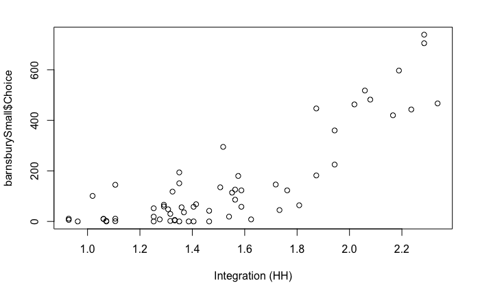

```r
plot(barnsburySmall$Integration_HH_, barnsburySmall$Choice, xlab = "Integration (HH)")
```

### Spatial Point Data

Spatial point data such as gatecounts can be loaded in the same way using readOGR().

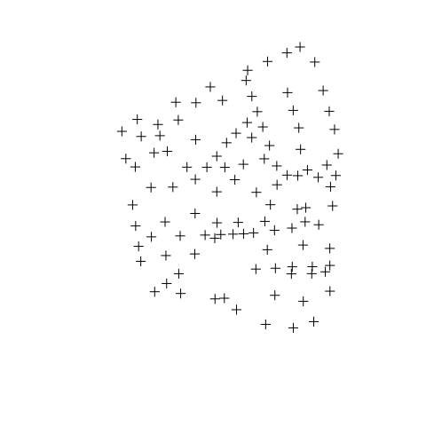

```r
gateCounts = readOGR("data/barnsbury/barnsbury_ped_gatecounts.mid", verbose = FALSE)
plot(gateCounts)
```

An interesting function to apply to point data is the convex hull, a polygon that includes all points and is convex. This can be done using the command gConvexHull.

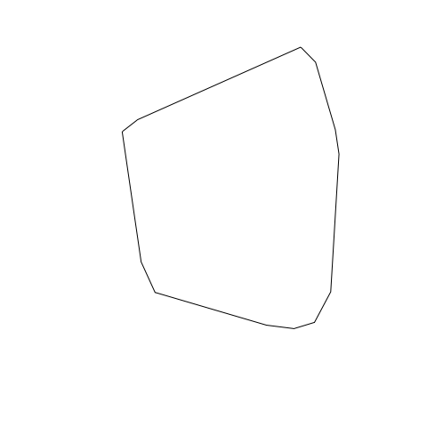

```r
chull = gConvexHull(gateCounts)
plot(chull)
```

### Spatial Line Data

Spatial line data such as axial and segment maps can be loaded in the same way using readOGR() which produces a SpatialLinesDataFrame. Here let’s load and plot a larger axial map of the Barnsbury area.

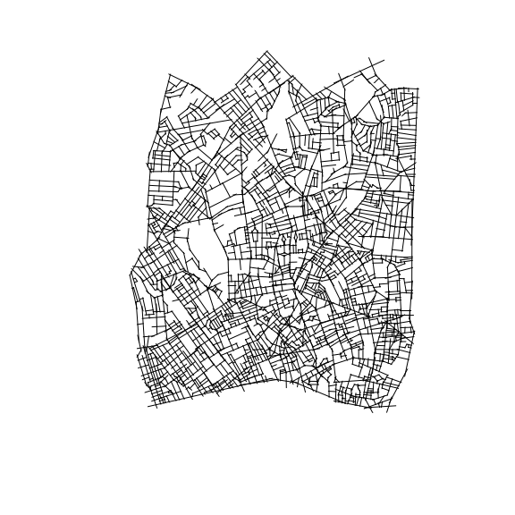

```r
barnsburyAxial = readOGR("data/barnsbury/barnsbury_axial.mid", verbose = FALSE)
plot(barnsburyAxial)
```

To plot each line a different colour depending on a column from the spatial data frame, we first produce a set of colours, in this case 100 colours from the heat.colors palette (type ?heat.colors to see more palettes contained in R by default). Then we call the cut() function which splits the values of integrations into 100 bins and matches each bin to each colour and thus each line.

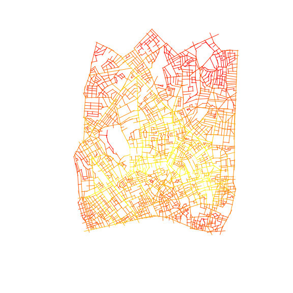

```r
cols = heat.colors(100)
plot(barnsburyAxial, col = cols[cut(barnsburyAxial$Integration, 100)])
```

An interesting function that relates to the SpatialLinesDataFrame is gLength() which gives the sum of lengths of all lines:

```r
gLength(barnsburyAxial)
```

```
[1] 249175.3
```

We can also get the length of each line by adding “byid = TRUE” to the gLength function. Here we make a histogram of all line lengths:

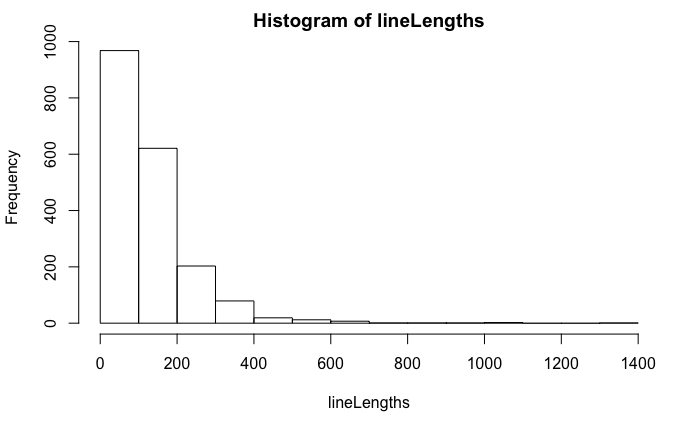

```r
lineLengths = gLength(barnsburyAxial, byid = TRUE)
hist(lineLengths)
```

Two plots may also be overlaid by calling them one after the other and providing “add = TRUE” for all plots apart from the first. The first plot defines the plot limits. Here let’s plot the large barnsbury map and add the gatecounts loaded previously:

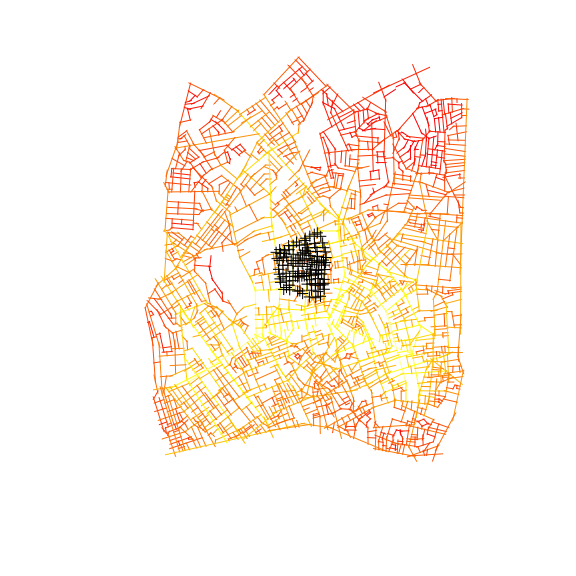

```r
plot(barnsburyAxial, col = cols[cut(barnsburyAxial$Integration, 100)])
plot(gateCounts, add = TRUE)
```

If the gatecounts are plotted first, then the plot limits are around them:

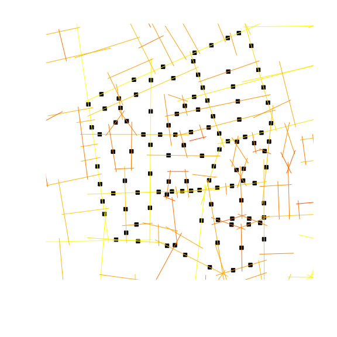

```r
plot(gateCounts, pch = 22)
plot(barnsburyAxial, col = cols[cut(barnsburyAxial$Integration, 100)], add = TRUE)
```

### Spatial Polygon Data

Spatial polygon data such as urban plots and building rooms can be loaded in the same way using readOGR() which produces a SpatialPolygonsDataFrame. Here let’s load and plot some generated urban plots of the Barnsbury area.

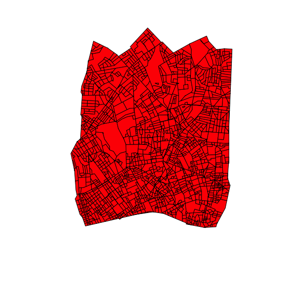

```r
barnsburyPlots = readOGR("data/barnsbury/barnsbury_plots.mid", verbose = FALSE)
plot(barnsburyPlots, col = "red")
```

Two useful functions for polygon data are gCentroid() which provides a SpatialPointsDataFrame with the centroids of the polygons and gArea() which gives the area of the polygons. These should be called with “byid = TRUE” to give the centroid and area for each polygon, otherwise they will provide a single point and number for the whole set of polygons. Here we generate the centroid and area and plot the polygons coloured by area with the centroids on top. Comments that will not be interpreted as code may be placed inside the chunk by starting a line with #

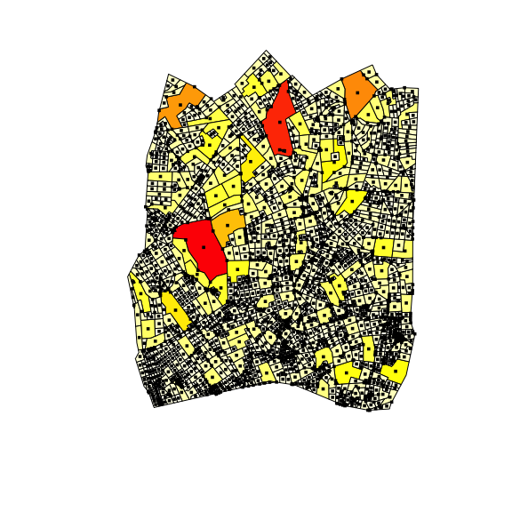

```r
plotCentroids = gCentroid(barnsburyPlots, byid = TRUE)
plotAreas = gArea(barnsburyPlots, byid = TRUE)
cols = rev(heat.colors(100))
plot(barnsburyPlots, col = cols[cut(plotAreas, 100)])
# pch is the shape of the points
# cex is the size of the points
plot(plotCentroids, add = TRUE, pch = 15, cex = 0.5, col = "black")
```

### Spatial Pixel Data

Spatial pixel data such as data from Visibility Graph Analysis (VGA) can be loaded in various ways to produce a SpatialPixelsDataFrame. Spatial pixels are essentially spatial points that are placed on a grid. To mark a SpatialPointsDataFrame as a SpatialPixelsDataFrame we need to call “gridded(SpatialPointsDataFrame) = TRUE”. Here, we’ll load the point data from a CSV as plain tabular data and then convert the plain data.frame to a SpatialPointsDataFrame using “coordinates(data.frame) = ~xcolumn+ycolumn”. Here let’s load the classic National Gallery VGA.

```r
galleryVGA = read.csv("data/gallery/gallery_vga.csv")
coordinates(galleryVGA) = ~x+y # converts data frame to spatialpointsdataframe
gridded(galleryVGA) = TRUE
names(galleryVGA) # print the column names of galleryVGA
```

```
 [1] "Ref"                          "Connectivity"                 "Point.First.Moment"
 [4] "Point.Second.Moment"          "Visual.Entropy"               "Visual.Integration..HH."
 [7] "Visual.Integration..P.value." "Visual.Integration..Tekl."    "Visual.Mean.Depth"
[10] "Visual.Node.Count"            "Visual.Relativised.Entropy"
```

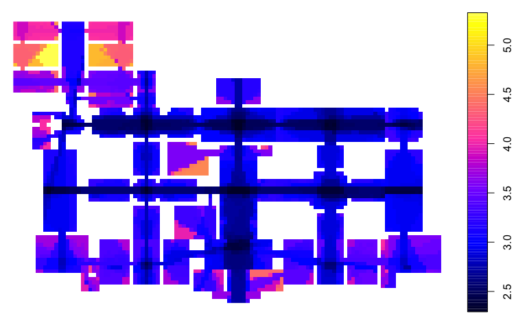

```r
plot(galleryVGA[, "Visual.Mean.Depth"])
```

## rdepthmap

This package was created in order to make the functionality of depthmapX available in R. It is a wrapper around depthmapXcli, the command line version of depthmap that contains only the core functionality and no Graphical User Interface. All functions are available in the Help section or by calling the function with a question mark in front. They can be called either with the prefix rdepthmap:: or just plain. Here, to make explicit which functions are part of the package they will be called with the prefix.

### rdepthmap: Axial analysis

A typical workflow when using depthmapX is to load line data, convert those lines to an axial map and then do axial analysis.

Let’s load line data into a GRAPH file:

```r
rdepthmap::importLines(barnsburySmall, "data/barnsburySmall.graph")
```

Then convert the line data inside the GRAPH file into an axial map and name that map “axial”

```r
rdepthmap::convertMap("data/barnsburySmall.graph",
                      newMapName = "Axial Map", newMapType = "axial")
```

```r
rdepthmap::axialAnalysis("data/barnsburySmall.graph", radii = c("n", "3"), includeChoice = TRUE, includeLocal = TRUE, includeIntermediateMetrics = FALSE)
```

Finally, let’s bring the data back into R using rdepthmap::getShapeGraph() to read the GRAPH file and take a look at the column names of our new SpatialLinesDataFrame.

```r
barnsburyAxialAnalysed = rdepthmap::getShapeGraph("data/barnsburySmall.graph")
names(barnsburyAxialAnalysed)
```

```
 [1] "Depthmap_Ref"           "Choice"                 "Choice_R3"              "Choice_Norm_"
 [5] "Choice_Norm_R3"         "Connectivity"           "Control"                "Controllability"
 [9] "Entropy"                "Entropy_R3"             "Harmonic_Mean_Depth"    "Harmonic_Mean_Depth_R3"
[13] "Integration_HH_"        "Integration_HH_R3"      "Integration_P_value_"   "Integration_P_value_R3"
[17] "Integration_Tekl_"      "Integration_Tekl_R3"    "Intensity"              "Intensity_R3"
[21] "Line_Length"            "Mean_Depth"             "Mean_Depth_R3"          "Node_Count"
[25] "Node_Count_R3"          "Relativised_Entropy"    "Relativised_Entropy_R3"
```

Let’s plot the newly analysed map, this time using one of depthmap’s palettes, provided by the package (Axmanesque is the default palette in depthmapX). We will also make the background of the map black using par(bg = “black”).

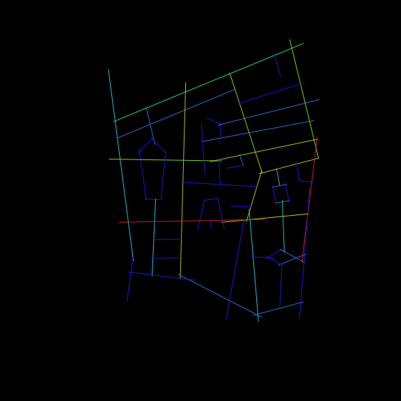

```r
cols = rdepthmap::depthmap.axmanesque.colour(100)
par(bg = "black")
plot(barnsburyAxialAnalysed, col = cols[cut(barnsburyAxialAnalysed$Choice, 100)])
```

### rdepthmap: Segment analysis

To carry out segment analysis, here we first convert the axial map to a segment map and then do segment analysis using three radii, “n”, 50 and 100. The radius type used is “metric”. As previously names() will give us the columns of our new SpatialLinesDataFrame.

```r
rdepthmap::convertMap("data/barnsburySmall.graph", "data/barnsburySegment.graph",
                      newMapName = "Segment map", newMapType = "segment",
                      stubLengthToRemove = 40, copyAttributes = TRUE)
rdepthmap::segmentAnalysis("data/barnsburySegment.graph", analysisType = "tulip",
                           radii = c("n", "50", "100"), radiusType = "metric",
                           tulip = 1024, includeChoice = TRUE,
                           weightWithColumn = "Segment Length")
segmentAnalysed = rdepthmap::getShapeGraph("data/barnsburySegment.graph")
names(segmentAnalysed)
```

```
 [1] "Depthmap_Ref"                    "Angular_Connectivity"            "Axial_Choice"
 [4] "Axial_Choice_R3"                 "Axial_Choice_Norm_"              "Axial_Choice_Norm_R3"
 [7] "Axial_Connectivity"              "Axial_Control"                   "Axial_Controllability"
[10] "Axial_Entropy"                   "Axial_Entropy_R3"                "Axial_Harmonic_Mean_Depth"
[13] "Axial_Harmonic_Mean_Depth_R3"    "Axial_Integration_HH_"           "Axial_Integration_HH_R3"
[16] "Axial_Integration_P_value_"      "Axial_Integration_P_value_R3"    "Axial_Integration_Tekl_"
[19] "Axial_Integration_Tekl_R3"       "Axial_Intensity"                 "Axial_Intensity_R3"
[22] "Axial_Line_Length"               "Axial_Line_Ref"                  "Axial_Mean_Depth"
[25] "Axial_Mean_Depth_R3"             "Axial_Node_Count"                "Axial_Node_Count_R3"
[28] "Axial_Relativised_Entropy"       "Axial_Relativised_Entropy_R3"    "Connectivity"
[31] "Segment_Length"                  "T1024_Choice"                    "T1024_Choice_R100_00_metric"
[34] "T1024_Choice_R50_00_metric"      "T1024_Choice_Segment_Length_Wgt" "T1024_Choice_Segment_Length_W_1"
[37] "T1024_Choice_Segment_Length_W_2" "T1024_Integration"               "T1024_Integration_R100_00_metri"
[40] "T1024_Integration_R50_00_metric" "T1024_Integration_Segment_Lengt" "T1024_Integration_Segment_Len_1"
[43] "T1024_Integration_Segment_Len_2" "T1024_Node_Count"                "T1024_Node_Count_R100_00_metric"
[46] "T1024_Node_Count_R50_00_metric"  "T1024_Total_Depth"               "T1024_Total_Depth_R100_00_metri"
[49] "T1024_Total_Depth_R50_00_metric" "T1024_Total_Depth_Segment_Lengt" "T1024_Total_Depth_Segment_Len_1"
[52] "T1024_Total_Depth_Segment_Len_2" "T1024_Total_Segment_Length"      "T1024_Total_Segment_Length_R100"
[55] "T1024_Total_Segment_Length_R50_"
```

Let’s then plot the segment map, using depthmapX “classic” palette:

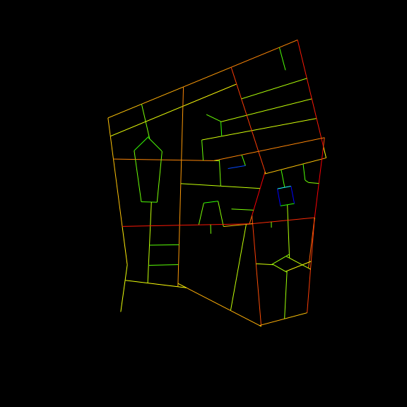

```r
cols = rdepthmap::depthmap.classic.colour(100)
par(bg = "black")
plot(segmentAnalysed, col = cols[cut(segmentAnalysed$T1024_Integration, 100)])
```

Another typical step of the workflow is to identify the “Integration core”. That is a subset of the lines the integration of which is above 90% of the overall integration of all lines. The rdepthmap package provides the function rdepthmap::getTopFeatures() for exactly this purpose, which will return the subset as a SpatialLinesDataFrame. Here, the integration core is plotted in thicker lines above the barnsbury segment model

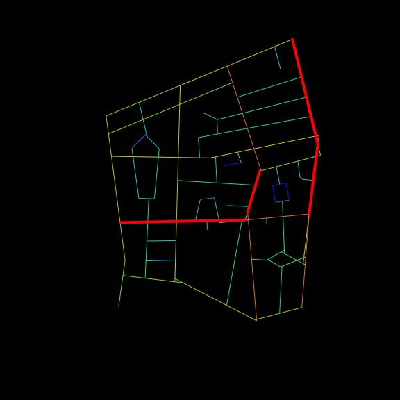

```r
integrationCore = rdepthmap::getTopFeatures(segmentAnalysed, "T1024_Integration", 0.1)
cols = rdepthmap::depthmap.axmanesque.colour(100)
par(bg = "black")
plot(segmentAnalysed[, "T1024_Integration"], col = cols[cut(segmentAnalysed$T1024_Integration, 100)], main = "Segment map with Integration core")
plot(integrationCore, add = TRUE, col = "red", lwd = 4)
```

```r
# rdepthmap::export("data/barnsburySmall.graph", "data/axialConnections.csv", exportType = "shapegraph-connections-csv")
```

### rdepthmap: Visibility Graph Analysis

Finally, we may perform VGA directly from R, by loading a floorplan into a graph, file, defining and filling a grid and carrying out the analysis.

The next chunk loads and plots a simplified National Gallery plan provided here as a pair of MIF/MID files. For more advanced floor-plan loading with more elements, look at the package dxfspatial

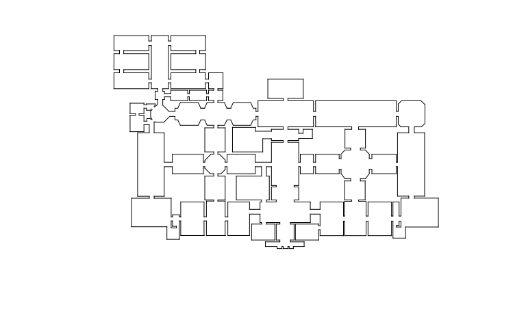

```r
galleryLines = readOGR("data/gallery/gallery_lines.mid", verbose = FALSE)
plot(galleryLines)
```

```r
rdepthmap::importLines(galleryLines, "data/gallery/gallery.graph")
rdepthmap::createGrid("data/gallery/gallery.graph", gridSize = 0.04)
rdepthmap::fillGrid("data/gallery/gallery.graph", fillX = 2.86, fillY = 6.68)
rdepthmap::makeVGAGraph("data/gallery/gallery.graph")
galleryVGA = rdepthmap::getPointmapData("data/gallery/gallery.graph")$map
names(galleryVGA)
```

```
[1] "Ref"                 "Connectivity"        "Point.First.Moment"  "Point.Second.Moment" "i"
[6] "j"
```

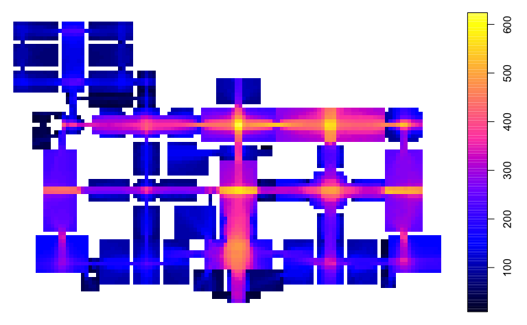

```r
plot(galleryVGA[, "Connectivity"])
```

We may also link coordinates (if for example we have different floors):

```r
rdepthmap::linkMapCoords("data/gallery/gallery.graph", linkFromX = 4.81, linkFromY = 6.67, linkToX = 2.39, linkToY = 5.23, mapTypeToLink = "pointmaps")
```

And then carry out VGA. The next chunk carries out two modes of VGA, “global-visibility” which calculates metrics such as Visual Mean Depth, Integration and “isovist”, which calculates metrics such as Isovist Area, Isovist Min Radial etc. See ?rdepthmap::VGA for more.

```r
rdepthmap::VGA("data/gallery/gallery.graph", vgaMode = "visibility-global", radii = c("n"))
rdepthmap::VGA("data/gallery/gallery.graph", vgaMode = "isovist", radii = c("n"))
galleryVGA = rdepthmap::getPointmapData("data/gallery/gallery.graph")$map
names(galleryVGA)
```

```
 [1] "Ref"                          "Connectivity"                 "Isovist.Area"
 [4] "Isovist.Compactness"          "Isovist.Drift.Angle"          "Isovist.Drift.Magnitude"
 [7] "Isovist.Max.Radial"           "Isovist.Min.Radial"           "Isovist.Occlusivity"
[10] "Isovist.Perimeter"            "Point.First.Moment"           "Point.Second.Moment"
[13] "Visual.Entropy"               "Visual.Integration..HH."      "Visual.Integration..P.value."
[16] "Visual.Integration..Tekl."    "Visual.Mean.Depth"            "Visual.Node.Count"
[19] "Visual.Relativised.Entropy"   "i"                            "j"
```

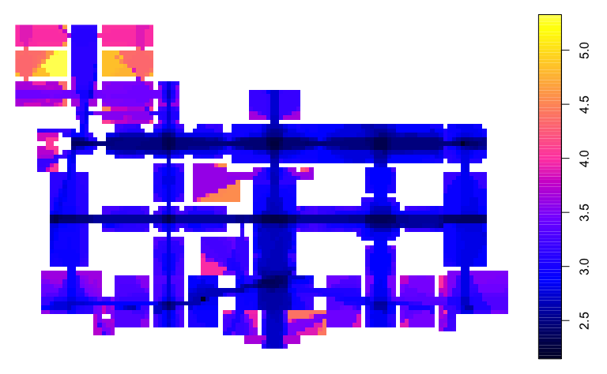

```r
plot(galleryVGA[, "Visual.Mean.Depth"])
```

We may also carry out Agent analysis after we have the grid using the command rdepthmap::agentAnalysis():

```r
rdepthmap::agentAnalysis("data/gallery/gallery.graph", lookMode = "standard", timesteps = 5000, releaseRate = 0.1, agentFOV = 16, agentSteps = 3, agentLife = 500)
galleryAgents = rdepthmap::getPointmapData("data/gallery/gallery.graph")$map
names(galleryAgents)
```

```
 [1] "Ref"                          "Connectivity"                 "Gate.Counts"
 [4] "Isovist.Area"                 "Isovist.Compactness"          "Isovist.Drift.Angle"
 [7] "Isovist.Drift.Magnitude"      "Isovist.Max.Radial"           "Isovist.Min.Radial"
[10] "Isovist.Occlusivity"          "Isovist.Perimeter"            "Point.First.Moment"
[13] "Point.Second.Moment"          "Visual.Entropy"               "Visual.Integration..HH."
[16] "Visual.Integration..P.value." "Visual.Integration..Tekl."    "Visual.Mean.Depth"
[19] "Visual.Node.Count"            "Visual.Relativised.Entropy"   "i"
[22] "j"
```

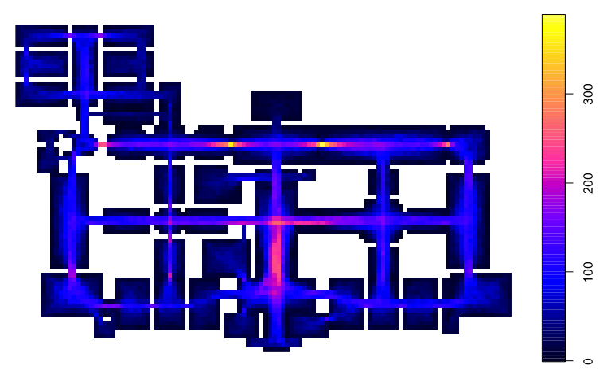

```r
plot(galleryAgents[, "Gate.Counts"])
```

## Statistics

### Simple aggregates

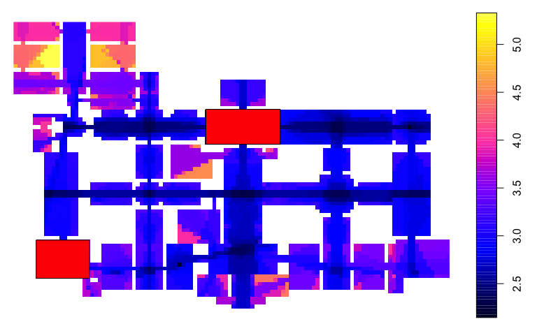

```r
galleryFunction = readOGR("data/gallery/gallery_polys.mid", verbose = FALSE)
plot(galleryVGA[, "Visual.Mean.Depth"])
plot(galleryFunction, add = TRUE, col = "red")
```

```r
overlapsDF = over(galleryVGA[, "Visual.Mean.Depth"], galleryFunction)
aggregate(galleryVGA$Visual.Integration..HH., by = list(overlapsDF$layer), mean)
```

| Group.1 | x |
| --- | --- |
| acc-gallery1 | 4.314054 |
| acc-gallery2 | 5.602548 |

In the same vain, let’s load some observed activity data and do a similar aggregation: First let’s load the snapshot data as a SpatialPointsDataFrame and add it to the plot as white dots.

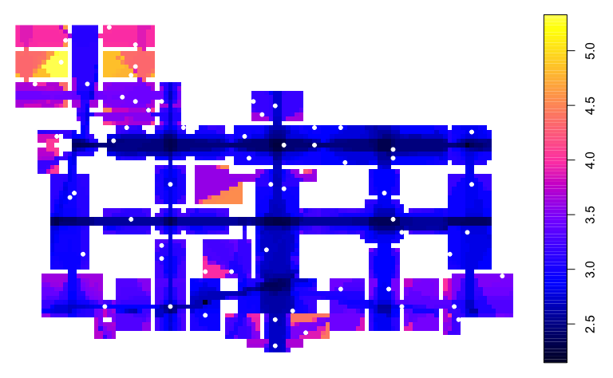

```r
gallerySnapshot = readOGR("data/gallery/gallery_snapshot.mid", verbose = FALSE)
plot(galleryVGA[, "Visual.Mean.Depth"])
plot(gallerySnapshot, add = TRUE, pch = 20, col = "white")
```

And then let’s find the number of people in each gally per activity:

```r
overlapsDF = over(gallerySnapshot[, "activity"], galleryFunction)
aggregate(gallerySnapshot$activity, by = list(overlapsDF$layer, gallerySnapshot$activity), length)
```

| Group.1 | Group.2 | x |
| --- | --- | --- |
| acc-gallery2 | standing | 5 |

### Simple correlation

To carry out simple correlation we’ll first load the large barnsbury axial map, convert it to a segment and compare it to gatecounts:

First the segment map:

```r
rdepthmap::importLines(barnsburyAxial, "data/barnsburyAxial.graph")
rdepthmap::convertMap("data/barnsburyAxial.graph",
                      newMapName = "Axial Map", newMapType = "axial")
rdepthmap::convertMap("data/barnsburyAxial.graph", "data/barnsburySegment.graph",
                      newMapName = "Segment map", newMapType = "segment",
                      stubLengthToRemove = 40, copyAttributes = TRUE)
rdepthmap::segmentAnalysis("data/barnsburySegment.graph", analysisType = "tulip",
                           radii = c("n", "50", "100"), radiusType = "metric",
                           tulip = 1024, includeChoice = TRUE,
                           weightWithColumn = "Segment Length")
segmentAnalysed = rdepthmap::getShapeGraph("data/barnsburySegment.graph")
```

Plot the segment map with the gatecounts loaded earlier

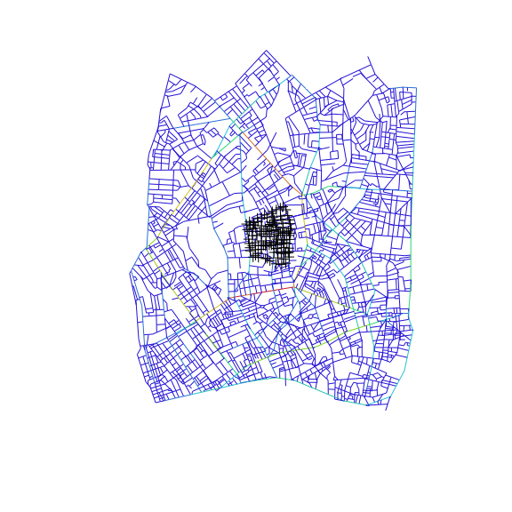

```r
cols = depthmap.axmanesque.colour(100)
plot(segmentAnalysed, col = cols[cut(segmentAnalysed$T1024_Choice, 100)])
plot(gateCounts, add = TRUE)
```

Then match the gatecount points to a line. Each point is assigned here to a single line and vice versa using the command rdepthmap::matchPointsToLines(). The gatecount data are then transferred as a column back into the SpatialLinesDataFrame using cbind()

```r
proj4string(segmentAnalysed) = CRS("")
proj4string(gateCounts) = CRS("")
matchedLines = rdepthmap::matchPointsToLines(gateCounts, segmentAnalysed)
segmentAnalysed@data = cbind(segmentAnalysed@data, matchedLines)
```

A simple linear model can then be carried out using lm() to create the model and summary() to see the statistics:

```r
frm = as.formula("mov_ped_ph ~ T1024_Choice")
mod = lm(frm, segmentAnalysed)
summary(mod)
```

```
Call:
lm(formula = frm, data = segmentAnalysed)

Residuals:
     Min       1Q   Median       3Q      Max
-109.461  -21.791   -7.019   22.562  122.813

Coefficients:
              Estimate Std. Error t value Pr(>|t|)
(Intercept)  4.553e+01  4.380e+00   10.40   <2e-16 ***
T1024_Choice 1.595e-04  8.371e-06   19.05   <2e-16 ***
---
Signif. codes:  0 ‘***’ 0.001 ‘**’ 0.01 ‘*’ 0.05 ‘.’ 0.1 ‘ ’ 1

Residual standard error: 37.94 on 107 degrees of freedom
  (7050 observations deleted due to missingness)
Multiple R-squared:  0.7724,    Adjusted R-squared:  0.7702
F-statistic:   363 on 1 and 107 DF,  p-value: < 2.2e-16
```

We may also plot the data in a scatterplot and add a regression line:

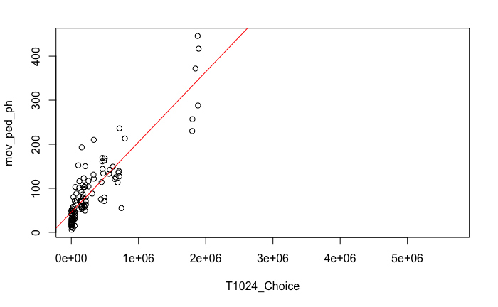

```r
plot(frm, data = segmentAnalysed)
abline(mod, col = "red")
```

To see residuals and other statistics the model may also be inserted into the plot() function

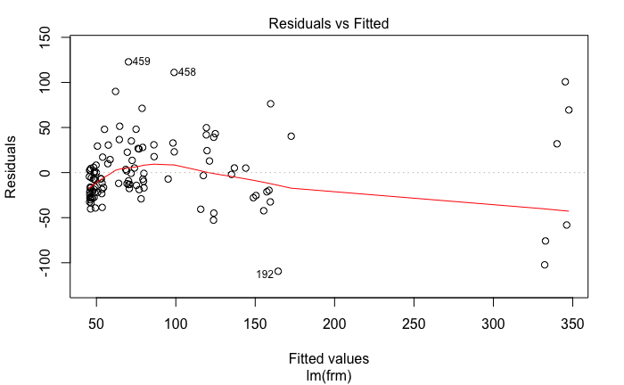

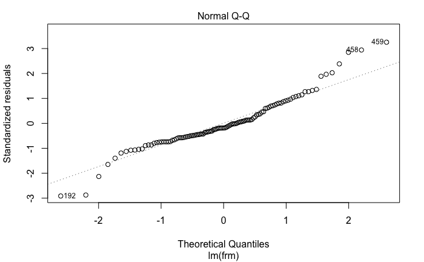

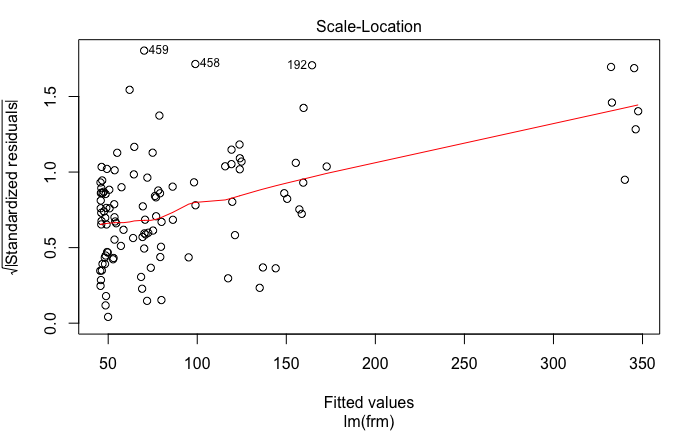

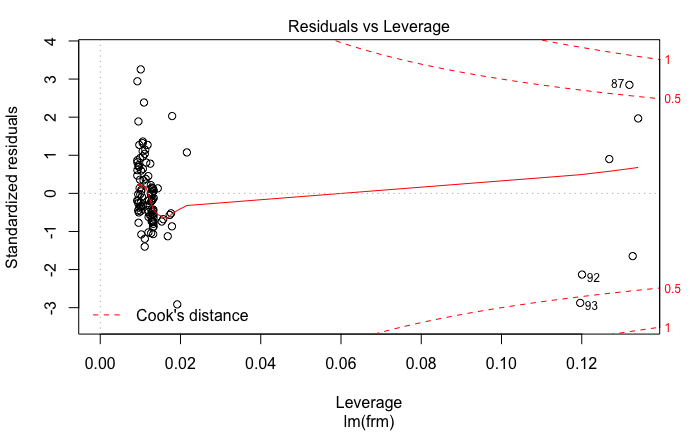

```r
plot(mod)
```

```r
frm = as.formula("mov_ped_ph ~ T1024_Choice+T1024_Integration")
mod = lm(frm, segmentAnalysed)
summary(mod)
```

```
Call:
lm(formula = frm, data = segmentAnalysed)

Residuals:
     Min       1Q   Median       3Q      Max
-117.458  -18.000   -4.902   18.070  119.756

Coefficients:
                    Estimate Std. Error t value Pr(>|t|)
(Intercept)       -4.187e+01  4.468e+01  -0.937    0.351
T1024_Choice       1.407e-04  1.266e-05  11.113   <2e-16 ***
T1024_Integration  5.150e-02  2.620e-02   1.965    0.052 .
---
Signif. codes:  0 ‘***’ 0.001 ‘**’ 0.01 ‘*’ 0.05 ‘.’ 0.1 ‘ ’ 1

Residual standard error: 37.44 on 106 degrees of freedom
  (7050 observations deleted due to missingness)
Multiple R-squared:  0.7804,    Adjusted R-squared:  0.7762
F-statistic: 188.3 on 2 and 106 DF,  p-value: < 2.2e-16
```